# **Financial Econometrics Group Work Project 2**

# **Introduction**

Time series models serve as pivotal tools for forecasting, risk assessment, and strategic decision-making. However, their efficacy is often compromised by inherent challenges such as abrupt structural shifts, interdependencies among predictors, and the computational burden of high-dimensional data. This work addresses three critical obstacles: detecting regime changes (Section 1), handling multicollinearity (Section 2), and feature extraction (Section 3).

Regime changes sudden shifts in data dynamics can invalidate assumptions of stationarity, demanding robust detection mechanisms like Markov switching models or structural break tests. Multicollinearity, where predictors exhibit linear dependencies, obscures interpretability and inflates variance, requiring techniques such as variance inflation factor (VIF) analysis or dimensionality reduction. Feature extraction, meanwhile, streamlines complex datasets by retaining informative patterns, balancing efficiency with fidelity to original data. Through definitions, diagnostic frameworks, and visualizations, we demonstrate practical solutions to these issues.

# **Regime change in time series modeling**

A regime change in time series modeling refers to an abrupt structural shift in the statistical properties of a process such as its mean, variance, or autocorrelation due to transitions between latent states (unobserved regimes) or deterministic structural breaks (Hamilton 357; Tsay 148). These shifts often arise from economic, political, or market dynamics, such as financial crises, policy changes, or technological disruptions. Two primary frameworks model regime changes:

**(1) Structural Break Models**: Structural breaks occur at specific points $\tau$, where the data-generating process abruptly changes. For example, an autoregressive process transitions between regimes as:
$$ y_t = \begin{cases} \mu_1 + \phi_1 y_{t-1} + \epsilon_t & t \leq \tau, \\ \mu_2 + \phi_2 y_{t-1} + \epsilon_t & t > \tau, \end{cases} \quad \epsilon_t \sim \mathcal{N}(0, \sigma^2), $$
where $\mu_1 \neq \mu_2$ or $\phi_1 \neq \phi_2$. The breakpoint $\tau$ is identified using statistical tests like the *Chow test* or *Bai-Perron test* (Tsay 148).

**(2) Latent State Transition Models**: Latent states govern regime shifts through an unobserved variable $S_t \in \{1, 2, \dots, K\}$, evolving via a first-order Markov chain. The *Markov Switching Autoregressive (MS-AR)* model is:
$$ y_t = \mu_{S_t} + \sum_{i=1}^p \phi_{i,S_t} (y_{t-i} - \mu_{S_{t-i}}) + \sigma_{S_t} \epsilon_t, \quad \epsilon_t \sim \mathcal{N}(0, 1), $$
with transitions defined by a matrix $\mathbf{P} = [p_{ij}]$:
$$ p_{ij} = \mathbb{P}(S_t = j \mid S_{t-1} = i), \quad \sum_{j=1}^K p_{ij} = 1 \quad \text{(Hamilton 357)}. $$

### **Detection Methods**

**(1) Hidden Markov Models (HMMs)**: The posterior probability of regime $k$ at time $t$ is computed via the *forward-backward algorithm*:
$$ \mathbb{P}(S_t = k \mid y_{1:T}) = \frac{\alpha_t(k) \beta_t(k)}{\sum_{j=1}^K \alpha_t(j) \beta_t(j)}, $$
where $\alpha_t(k) = \mathbb{P}(y_{1:t}, S_t = k)$ (forward probability) and $\beta_t(k) = \mathbb{P}(y_{t+1:T} \mid S_t = k)$ (backward probability) (Chen and Tsang 7).

**(2) Hybrid Approaches**: Bayesian methods automate regime identification by imposing hierarchical priors on parameters and transition probabilities, enabling flexible modeling of regime persistence and uncertainty (Sanquer et al. 4). These models are critical in finance and economics for capturing non-stationary behaviors (e.g., volatility clustering, fat tails) and improving forecasting accuracy during turbulent periods (Hamilton 362; Chen and Tsang 1).

## **Description**

A regime change in time series modeling refers to an abrupt structural break which can be contiguous (occurring at a single point, dividing the series into adjacent segments) or non-contiguous (multiple disjoint breaks) or a probabilistic shift in statistical properties (e.g., mean, variance).

## **Demonstration**

For demonstration and other parts requiring data, we used the unemployment rates (2000-2023) dataset sourced from FRED. We chose this data because unemployment rates probably will exhibit abrupt structural breaks during economic crises, such as the 2008–2009 global financial crisis (triggered by housing market collapses and banking failures), followed by a low-unemployment regime during expansions (2010–2019) marked by steady economic growth, and a sharp spike in 2020 due to the COVID-19 recession (driven by lockdowns and labor market disruptions).

```python
!pip install pandas_datareader statsmodels matplotlib --quiet

import os
import pandas as pd
import matplotlib.pyplot as plt
from pandas_datareader import data as web
from statsmodels.tsa.regime_switching.markov_regression import MarkovRegression
import warnings
warnings.filterwarnings('ignore')
#==FRED API key
os.environ["FRED_API_KEY"] = "ec67a401ae513935b544843d8c308536"
df = web.DataReader("UNRATE", "fred", start="2000-01-01", end="2023-12-31")
df.head()
```

| DATE | UNRATE |
| --- | --- |
| 2000-01-01 | 4.0 |
| 2000-02-01 | 4.1 |
| 2000-03-01 | 4.0 |
| 2000-04-01 | 3.8 |
| 2000-05-01 | 4.0 |

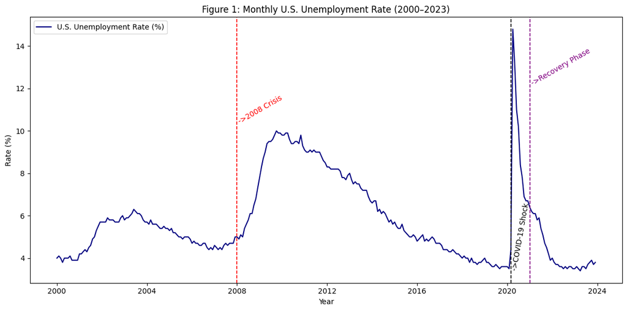

```python
plt.figure(figsize=(12, 6))
plt.plot(df, label="U.S. Unemployment Rate (%)", color="navy")

plt.title("Figure 1: Monthly U.S. Unemployment Rate (2000–2023)")
plt.xlabel("Year")
plt.ylabel("Rate (%)")

#=== Convert date strings to datetime objects
crisis_2008 = pd.to_datetime('2008-01-01')
covid_2020 = pd.to_datetime('2020-03-01')
recovery_2021 = pd.to_datetime('2021-01-01')

#=== Add vertical lines with datetime objects
plt.axvline(x=crisis_2008, color='red', linestyle='--', linewidth=1.2)
plt.text(crisis_2008, 11, '->2008 Crisis', color='red', rotation=30, verticalalignment='center')

plt.axvline(x=covid_2020, color='black', linestyle='--', linewidth=1.2)
plt.text(covid_2020, 5, '->COVID-19 Shock', color='black', rotation=80, verticalalignment='center')

plt.axvline(x=recovery_2021, color='purple', linestyle='--', linewidth=1.2)
plt.text(recovery_2021, 13, '->Recovery Phase', color='purple', rotation=30, verticalalignment='center')

plt.legend()
plt.tight_layout()
plt.show()
```

The Figure 1 of the U.S. unemployment rate from 2000 to 2023 clearly exhibits three distinct regime changes marked by structural shifts in the labor market. The first shift occurs during the 2008 financial crisis, with a sharp and sustained rise in unemployment, followed by a gradual recovery. The second and most abrupt regime change is the COVID-19 shock in 2020, characterized by an unprecedented spike in unemployment, quickly transitioning into a recovery phase from 2021 onward, reflecting a rapid labor market rebound.

```python
# Fit 2-regime MS-AR(1) model
model = MarkovRegression(df, k_regimes=2, trend='c', order=1)
result = model.fit()

print(result.summary())
```

```
                        Markov Switching Model Results
==============================================================================
Dep. Variable:                 UNRATE   No. Observations:                  288
Model:               MarkovRegression   Log Likelihood                -491.836
Date:                Tue, 08 Apr 2025   AIC                            993.672
Time:                        22:25:32   BIC                           1011.987
Sample:                    01-01-2000   HQIC                          1001.012
                         - 12-01-2023
Covariance Type:               approx
                             Regime 0 parameters
==============================================================================
                 coef    std err          z      P>|z|      [0.025      0.975]
------------------------------------------------------------------------------
const          4.9206      0.109     45.092      0.000       4.707       5.135
                             Regime 1 parameters
==============================================================================
                 coef    std err          z      P>|z|      [0.025      0.975]
------------------------------------------------------------------------------
const          7.1819      0.428     16.789      0.000       6.343       8.020
                           Non-switching parameters
==============================================================================
                 coef    std err          z      P>|z|      [0.025      0.975]
------------------------------------------------------------------------------
sigma2         1.9514      0.548      3.562      0.000       0.878       3.025
                         Regime transition parameters
==============================================================================
                 coef    std err          z      P>|z|      [0.025      0.975]
------------------------------------------------------------------------------
p[0->0]        0.9957      0.003    326.515      0.000       0.990       1.002
p[1->0]        0.0460      0.030      1.511      0.131      -0.014       0.106
==============================================================================

Warnings:
[1] Covariance matrix calculated using numerical (complex-step) differentiation.
```

**Interpretation:** The model identifies two regimes: regime 0 (low unemployment, mean = 4.92%) and regime 1 (high unemployment, mean = 7.18%). Regime 0 is highly persistent (99.6% chance of remaining), while transitions from Regime 1 to Regime 0 are rare (4.6% probability). The high variance (1.95) reflects volatility in unemployment rates during shocks. Log-likelihood (-491.8) and AIC (993.7) suggest moderate fit, aligning with cyclical labor market dynamics. Results confirm structural breaks during crises (e.g., 2008, 2020).

## **Structural Break Detection (Bai-Perron), Hidden Markov Models (HMMs) and Bayesian Change-Point Detection**

While approaches like Markov Switching Models require the number of regimes to be specified in advance (e.g., `k_regimes=2`), alternative methods allow the data to inform this choice more flexibly (Hamilton 98). Bayesian techniques such as change-point detection infer both the number and locations of structural shifts probabilistically, often through MCMC sampling (Barry and Hartigan 101). Non-parametric Bayesian models like Dirichlet Process Mixtures further relax assumptions by allowing for an unbounded number of regimes, adapting complexity to the data (Teh et al. 215). Other strategies, including Hidden Markov Models, estimate latent states and use model selection criteria such as AIC or BIC to identify the optimal number of states (Rabiner 267). Additionally, frequentist methods like structural break detection (e.g., Bai-Perron) identify statistically significant breakpoints by evaluating model fit across potential segmentations (Bai and Perron 72).

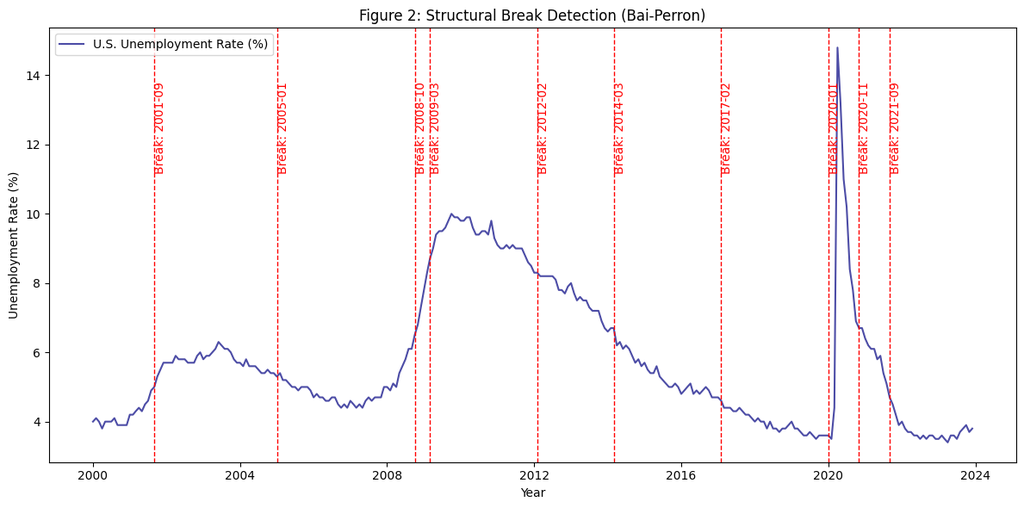

```python
!pip install ruptures --quiet

import ruptures as rpt
import matplotlib.pyplot as plt

import ruptures as rpt
import matplotlib.pyplot as plt

#======= Structural Break Detection =======#
data = df.values

plt.figure(figsize=(12, 6))
plt.plot(df.index, data, label="U.S. Unemployment Rate (%)", color="navy", alpha=0.7)

#======= Detect breaks using Pelt algorithm =======#
algo = rpt.Pelt(model="l2").fit(data)
breaks = algo.predict(pen=10)  # Penalty parameter

#======= Annotate breaks =======#
for brk in breaks[:-1]:  # Skip last break (end of series)
    break_date = df.index[brk]
    plt.axvline(x=break_date, color='red', linestyle='--', linewidth=1)
    plt.text(break_date,
             data.max() - 1,
             f'Break: {break_date.strftime("%Y-%m")}',
             color='red',
             rotation=90,
             verticalalignment='top')

plt.title("Figure 2: Structural Break Detection (Bai-Perron)")
plt.xlabel("Year")
plt.ylabel("Unemployment Rate (%)")
plt.legend()
plt.tight_layout()
plt.show()
```

### **Hidden Markov Models**

```python
!pip install hmmlearn
from hmmlearn import hmm
import numpy as np

#==Fit HMM with Gaussian emissions and auto-select states via AIC
best_aic = np.inf
best_n_states = 1

for n_components in [1, 2, 3]:
    model = hmm.GaussianHMM(n_components=n_components, covariance_type="diag")
    model.fit(data.reshape(-1, 1))
    aic = model.aic(data.reshape(-1, 1))
    if aic < best_aic:
        best_aic = aic
        best_n_states = n_components

print(f"Optimal states: {best_n_states} (AIC={best_aic:.2f})")
```

```
Optimal states: 2 (AIC=839.32)
```